# Tugas Praktikum 3

```r
library(dplyr)
library(TTR)
library(forecast)
library(lmtest)
library(orcutt)
library(HoRM)
```

# Data 1

```r
library(readxl)

data1 <- read_excel("C:\\Users\\Asus\\Downloads\\data_market_share_price.xlsx")
data1
```

```
## # A tibble: 20 × 3
##    Period `Market share` Price
##     <dbl>          <dbl> <dbl>
##  1      1           3.63  0.97
##  2      2           4.2   0.95
##  3      3           3.33  0.99
##  4      4           4.54  0.91
##  5      5           2.89  0.98
##  6      6           4.87  0.9
##  7      7           4.9   0.89
##  8      8           5.29  0.86
##  9      9           6.18  0.85
## 10     10           7.2   0.82
## 11     11           7.25  0.79
## 12     12           6.09  0.83
## 13     13           6.8   0.81
## 14     14           8.65  0.77
## 15     15           8.43  0.76
## 16     16           8.29  0.8
## 17     17           7.18  0.83
## 18     18           7.9   0.79
## 19     19           8.45  0.76
## 20     20           8.23  0.78
```

```r
data1 <- data1 %>%
  rename(market.share = `Market share`)

data1
```

```
## # A tibble: 20 × 3
##    Period market.share Price
##     <dbl>        <dbl> <dbl>
##  1      1         3.63  0.97
##  2      2         4.2   0.95
##  3      3         3.33  0.99
##  4      4         4.54  0.91
##  5      5         2.89  0.98
##  6      6         4.87  0.9
##  7      7         4.9   0.89
##  8      8         5.29  0.86
##  9      9         6.18  0.85
## 10     10         7.2   0.82
## 11     11         7.25  0.79
## 12     12         6.09  0.83
## 13     13         6.8   0.81
## 14     14         8.65  0.77
## 15     15         8.43  0.76
## 16     16         8.29  0.8
## 17     17         7.18  0.83
## 18     18         7.9   0.79
## 19     19         8.45  0.76
## 20     20         8.23  0.78
```

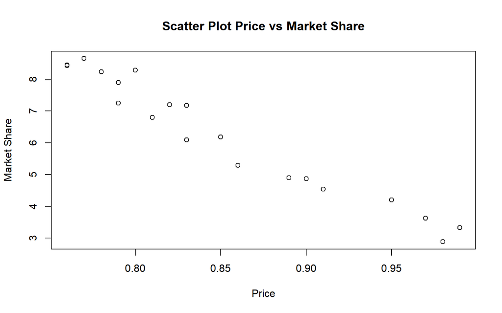

```r
plot(data1$Price, data1$market.share,
     xlab = "Price",
     ylab = "Market Share",
     main = "Scatter Plot Price vs Market Share")
```

```r
cor(data1$Price, data1$market.share)
```

```
## [1] -0.9752564
```

## Regresi 1

```r
model1 <- lm(market.share ~ Price, data = data1)

summary(model1)
```

```
##
## Call:
## lm(formula = market.share ~ Price, data = data1)
##
## Residuals:
##      Min       1Q   Median       3Q      Max
## -0.73068 -0.29764 -0.00966  0.30224  0.81193
##
## Coefficients:
##             Estimate Std. Error t value Pr(>|t|)
## (Intercept)   26.910      1.110   24.25 3.39e-15 ***
## Price        -24.290      1.298  -18.72 3.02e-13 ***
## ---
## Signif. codes:  0 '***' 0.001 '**' 0.01 '*' 0.05 '.' 0.1 ' ' 1
##
## Residual standard error: 0.4287 on 18 degrees of freedom
## Multiple R-squared:  0.9511, Adjusted R-squared:  0.9484
## F-statistic: 350.3 on 1 and 18 DF,  p-value: 3.019e-13
```

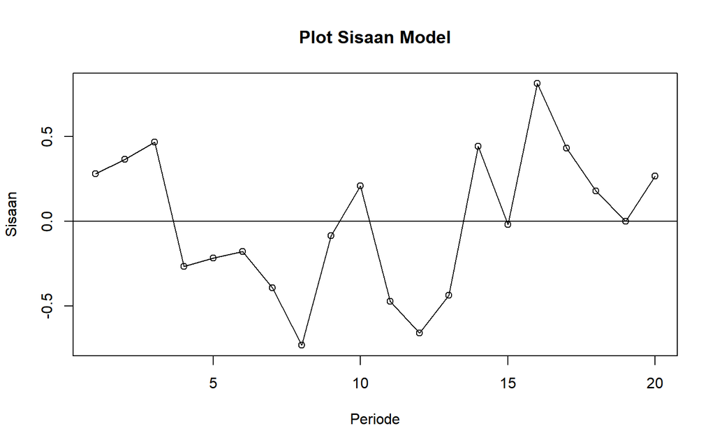

```r
sisaan1 <- residuals(model1)

plot(sisaan1,
     type = "o",
     xlab = "Periode",
     ylab = "Sisaan",
     main = "Plot Sisaan Model")

abline(h = 0)
```

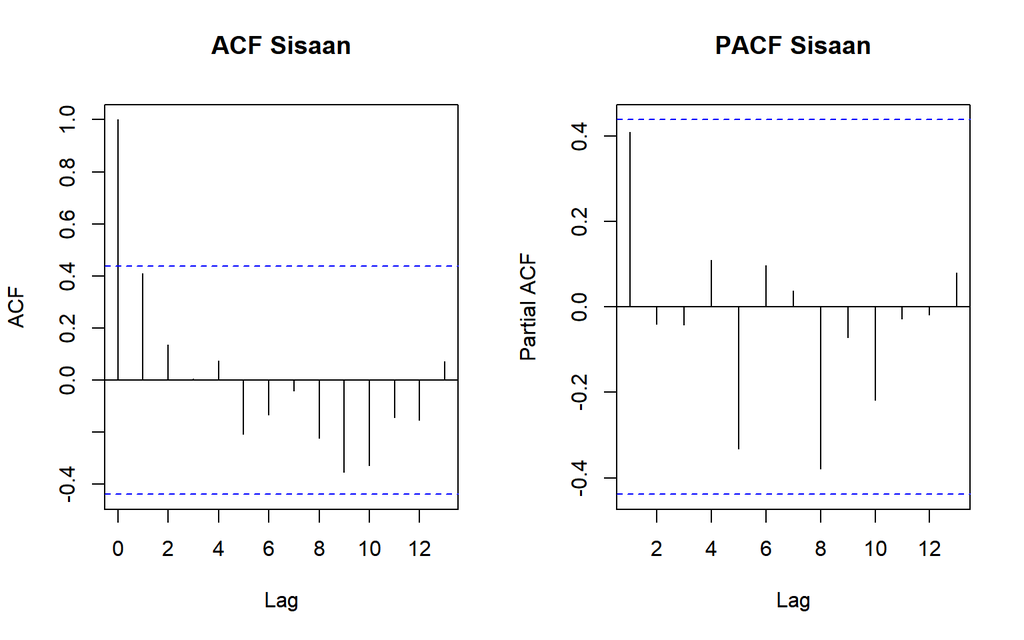

```r
par(mfrow = c(1,2))

acf(sisaan1,
    main = "ACF Sisaan")

pacf(sisaan1,
     main = "PACF Sisaan")
```

```r
dwtest(model1)
```

```
##
##  Durbin-Watson test
##
## data:  model1
## DW = 1.1358, p-value = 0.009813
## alternative hypothesis: true autocorrelation is greater than 0
```

Berdasarkan plot sisaan, ACF, dan PACF, terlihat adanya indikasi autokorelasi pada sisaan. Selanjutnya, dilakukan uji formal menggunakan uji Durbin-Watson. Berdasarkan hasil uji Durbin-Watson, diperoleh nilai $DW = 1.1358$ dan $p-value = 0.009813$. Dengan menggunakan taraf nyata 5%, diperoleh p-value < 0.05 sehingga H0 ditolak. Artinya, terdapat cukup bukti untuk menyatakan bahwa terdapat autokorelasi positif pada sisaan model. Oleh karena itu, diperlukan penanganan autokorelasi. Penanganan selanjutnya dilakukan menggunakan metode Cochrane-Orcutt dan Hildreth-Lu.

## Penangagan Data 1

### Cochrane-Orcutt

```r
model1CO <- cochrane.orcutt(model1)

model1CO
```

```
## Cochrane-orcutt estimation for first order autocorrelation
##
## Call:
## lm(formula = market.share ~ Price, data = data1)
##
##  number of interaction: 8
##  rho 0.425232
##
## Durbin-Watson statistic
## (original):    1.13582 , p-value: 9.813e-03
## (transformed): 1.95804 , p-value: 4.151e-01
##
##  coefficients:
## (Intercept)       Price
##    26.72209   -24.08413
```

```r
rho1<- model1CO$rho
rho1
```

```
## [1] 0.4252321
```

```r
market.share.trans <- data1$market.share[-1] -
  data1$market.share[-20] * rho1

price.trans <- data1$Price[-1] -
  data1$Price[-20] * rho1

model1COmanual <- lm(market.share.trans ~ price.trans)

summary(model1COmanual)
```

```
##
## Call:
## lm(formula = market.share.trans ~ price.trans)
##
## Residuals:
##      Min       1Q   Median       3Q      Max
## -0.55508 -0.25069 -0.05506  0.25007  0.83017
##
## Coefficients:
##             Estimate Std. Error t value Pr(>|t|)
## (Intercept)  15.3590     0.9385   16.36 7.71e-12 ***
## price.trans -24.0841     1.9385  -12.42 5.90e-10 ***
## ---
## Signif. codes:  0 '***' 0.001 '**' 0.01 '*' 0.05 '.' 0.1 ' ' 1
##
## Residual standard error: 0.3955 on 17 degrees of freedom
## Multiple R-squared:  0.9008, Adjusted R-squared:  0.895
## F-statistic: 154.4 on 1 and 17 DF,  p-value: 5.903e-10
```

```r
b0bintang <- model1COmanual$coefficients[-2]

b0 <- b0bintang/(1-rho1)

b1 <- model1COmanual$coefficients[-1]

b0
```

```
## (Intercept)
##    26.72209
```

```r
b1
```

```
## price.trans
##   -24.08413
```

```r
dwtest(model1COmanual)
```

```
##
##  Durbin-Watson test
##
## data:  model1COmanual
## DW = 1.958, p-value = 0.4151
## alternative hypothesis: true autocorrelation is greater than 0
```

Berdasarkan hasil uji Durbin-Watson setelah dilakukan penanganan autokorelasi menggunakan metode Cochrane-Orcutt, diperoleh nilai $DW = 1,958$ dan $p-value = 0,4151$. Pada taraf nyata 5%, p-value > 0,05 sehingga H0 tidak ditolak. Dengan demikian, tidak terdapat cukup bukti adanya autokorelasi positif pada sisaan model setelah dilakukan penanganan menggunakan metode Cochrane-Orcutt.

### Hiderth-lu

```r
hildreth.lu.func <- function(r, model1){
  x <- model.matrix(model1)[,-1]
  y <- model.response(model.frame(model1))
  n <- length(y)
  t <- 2:n
  y <- y[t]-r*y[t-1]
  x <- x[t]-r*x[t-1]

  return(lm(y~x))
}


r <- c(seq(0.1,0.9, by = 0.1))

tab <- data.frame(
  "rho" = r,
  "SSE" = sapply(r, function(i){
    deviance(hildreth.lu.func(i, model1))
  })
)

round(tab, 4)
```

```
##   rho    SSE
## 1 0.1 2.9791
## 2 0.2 2.8105
## 3 0.3 2.7052
## 4 0.4 2.6612
## 5 0.5 2.6749
## 6 0.6 2.7420
## 7 0.7 2.8588
## 8 0.8 3.0265
## 9 0.9 3.2529
```

```r
rOpt <- seq(0.2,0.5, by = 0.001)

tabOpt <- data.frame(
  "rho" = rOpt,
  "SSE" = sapply(rOpt, function(i){
    deviance(hildreth.lu.func(i, model1))
  })
)

head(tabOpt[order(tabOpt$SSE),])
```

```
##       rho      SSE
## 226 0.425 2.659368
## 227 0.426 2.659370
## 225 0.424 2.659372
## 228 0.427 2.659377
## 224 0.423 2.659382
## 229 0.428 2.659390
```

```r
modelHL1 <- hildreth.lu.func(0.425  , model1)

summary(modelHL1)
```

```
##
## Call:
## lm(formula = y ~ x)
##
## Residuals:
##      Min       1Q   Median       3Q      Max
## -0.55517 -0.25066 -0.05505  0.25010  0.83017
##
## Coefficients:
##             Estimate Std. Error t value Pr(>|t|)
## (Intercept)  15.3655     0.9387   16.37 7.68e-12 ***
## x           -24.0848     1.9380  -12.43 5.88e-10 ***
## ---
## Signif. codes:  0 '***' 0.001 '**' 0.01 '*' 0.05 '.' 0.1 ' ' 1
##
## Residual standard error: 0.3955 on 17 degrees of freedom
## Multiple R-squared:  0.9008, Adjusted R-squared:  0.895
## F-statistic: 154.4 on 1 and 17 DF,  p-value: 5.88e-10
```

```r
cat("Market Share = ",
    coef(modelHL1)[1]/(1-0.425),
    "+",
    coef(modelHL1)[2],
    "Price",
    sep = "")
```

```
## Market Share = 26.72268+-24.08484Price
```

```r
dwtest(modelHL1)
```

```
##
##  Durbin-Watson test
##
## data:  modelHL1
## DW = 1.9577, p-value = 0.4148
## alternative hypothesis: true autocorrelation is greater than 0
```

Berdasarkan hasil uji Durbin-Watson setelah dilakukan penanganan autokorelasi menggunakan metode Hildreth-Lu dengan nilai $\rho=0.425$, diperoleh nilai $DW=1.9577$ dan p-value sebesar 0.4148. Pada taraf nyata 5%, diperoleh p-value > 0.05 sehingga H0 tidak ditolak. Dengan demikian, tidak terdapat cukup bukti adanya autokorelasi positif pada sisaan setelah dilakukan penanganan menggunakan metode Hildreth-Lu.

# Data 2

```r
data2 <- read_excel("C:\\Users\\Asus\\Downloads\\data_sales_advertising.xlsx")
data2
```

```
## # A tibble: 40 × 3
##     Year Sales Advertising
##    <dbl> <dbl>       <dbl>
##  1  1975  11.7         9.4
##  2  1976  12           9.6
##  3  1977  12.3        10
##  4  1978  12.8        10.4
##  5  1979  13.1        10.8
##  6  1980  13.6        10.9
##  7  1981  13.9        11.7
##  8  1982  14.4        12.2
##  9  1983  14.7        12.5
## 10  1984  15.3        12.9
## # ℹ 30 more rows
```

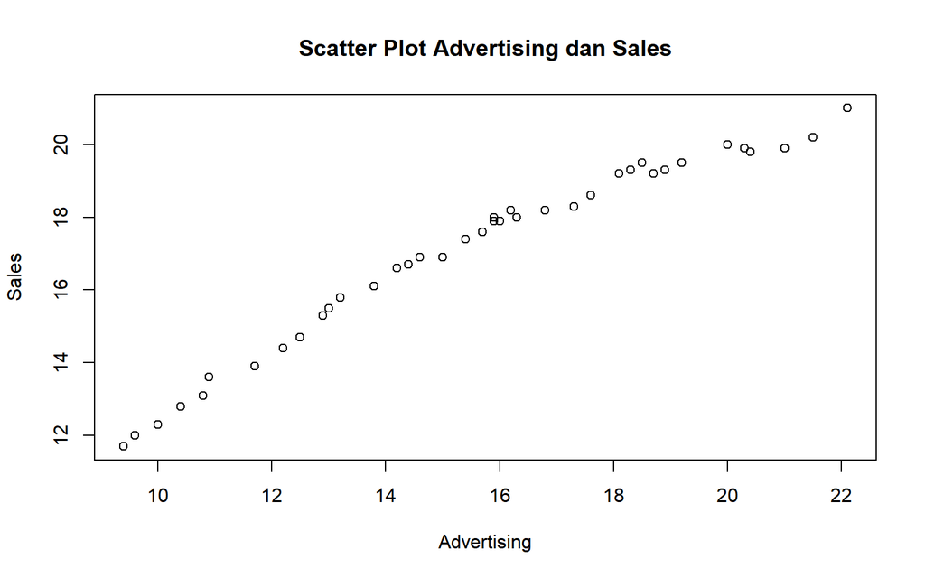

```r
plot(data2$Advertising, data2$Sales,
     xlab = "Advertising",
     ylab = "Sales",
     main = "Scatter Plot Advertising dan Sales")
```

```r
cor(data2$Advertising, data2$Sales)
```

```
## [1] 0.9795849
```

## Regresi OLS 2

```r
model2 <- lm(Sales ~ Advertising, data = data2)

summary(model2)
```

```
##
## Call:
## lm(formula = Sales ~ Advertising, data = data2)
##
## Residuals:
##      Min       1Q   Median       3Q      Max
## -1.03758 -0.40343  0.08933  0.45674  0.74036
##
## Coefficients:
##             Estimate Std. Error t value Pr(>|t|)
## (Intercept)  5.96513    0.38092   15.66   <2e-16 ***
## Advertising  0.71035    0.02365   30.04   <2e-16 ***
## ---
## Signif. codes:  0 '***' 0.001 '**' 0.01 '*' 0.05 '.' 0.1 ' ' 1
##
## Residual standard error: 0.527 on 38 degrees of freedom
## Multiple R-squared:  0.9596, Adjusted R-squared:  0.9585
## F-statistic: 902.3 on 1 and 38 DF,  p-value: < 2.2e-16
```

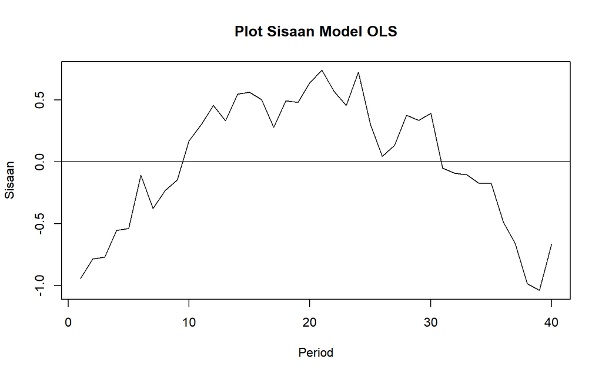

```r
sisaan2 <- residuals(model2)

plot(sisaan2,
     type = "l",
     xlab = "Period",
     ylab = "Sisaan",
     main = "Plot Sisaan Model OLS")

abline(h = 0)
```

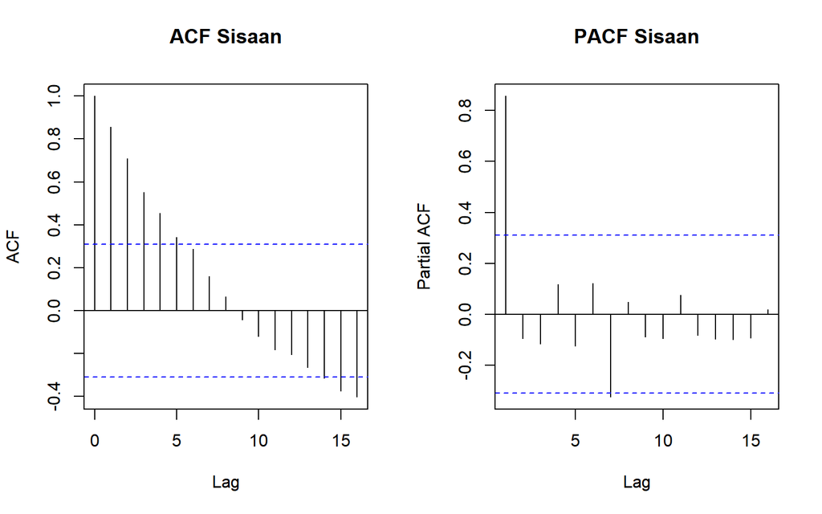

```r
par(mfrow = c(1,2))

acf(sisaan2,
    main = "ACF Sisaan")

pacf(sisaan2,
     main = "PACF Sisaan")
```

```r
dwtest(model2)
```

```
##
##  Durbin-Watson test
##
## data:  model2
## DW = 0.16204, p-value < 2.2e-16
## alternative hypothesis: true autocorrelation is greater than 0
```

Berdasarkan hasil uji Durbin-Watson pada model OLS, diperoleh nilai $DW = 0,16204$ dengan $p-value < 2,2 × 10⁻¹⁶$. Pada taraf nyata 5%, p-value < 0,05 sehingga H₀ ditolak dan H₁ diterima. Dengan demikian, terdapat autokorelasi positif pada sisaan model OLS. Hal ini juga didukung oleh plot sisaan, ACF, dan PACF yang menunjukkan adanya pola pada sisaan. Oleh karena itu, diperlukan penanganan autokorelasi menggunakan metode Cochrane-Orcutt dan Hildreth-Lu.

## Penanganan Data 2

### Cochrane-Orcutt

```r
model2CO <- cochrane.orcutt(model2)

summary(model2CO)
```

```
## Call:
## lm(formula = Sales ~ Advertising, data = data2)
##
##              Estimate Std. Error t value  Pr(>|t|)
## (Intercept) 10.252375   1.459736   7.023 2.638e-08 ***
## Advertising  0.488489   0.075426   6.476 1.426e-07 ***
## ---
## Signif. codes:  0 '***' 0.001 '**' 0.01 '*' 0.05 '.' 0.1 ' ' 1
##
## Residual standard error: 0.1868 on 37 degrees of freedom
## Multiple R-squared:  0.5313 ,  Adjusted R-squared:  0.5186
## F-statistic: 41.9 on 1 and 37 DF,  p-value: < 1.426e-07
##
## Durbin-Watson statistic
## (original):    0.16204 , p-value: 8.935e-20
## (transformed): 1.93925 , p-value: 3.78e-01
```

```r
rho2 <- model2CO$rho
rho2
```

```
## [1] 0.9031233
```

```r
Y2 <- data2$Sales
X2 <- data2$Advertising

n2 <- length(Y2)

Y2.trans <- Y2[-1] - Y2[-n2] * rho2
X2.trans <- X2[-1] - X2[-n2] * rho2

model2COmanual <- lm(Y2.trans ~ X2.trans)

summary(model2COmanual)
```

```
##
## Call:
## lm(formula = Y2.trans ~ X2.trans)
##
## Residuals:
##      Min       1Q   Median       3Q      Max
## -0.37730 -0.14957  0.01257  0.10464  0.45315
##
## Coefficients:
##             Estimate Std. Error t value Pr(>|t|)
## (Intercept)  0.99322    0.14141   7.023 2.64e-08 ***
## X2.trans     0.48849    0.07543   6.476 1.43e-07 ***
## ---
## Signif. codes:  0 '***' 0.001 '**' 0.01 '*' 0.05 '.' 0.1 ' ' 1
##
## Residual standard error: 0.1868 on 37 degrees of freedom
## Multiple R-squared:  0.5313, Adjusted R-squared:  0.5186
## F-statistic: 41.94 on 1 and 37 DF,  p-value: 1.426e-07
```

```r
b0bintang2 <- model2COmanual$coefficients[-2]

b0_2 <- b0bintang2/(1-rho2)

b1_2 <- model2COmanual$coefficients[-1]

b0_2
```

```
## (Intercept)
##    10.25237
```

```r
b1_2
```

```
##  X2.trans
## 0.4884891
```

```r
dwtest(model2COmanual)
```

```
##
##  Durbin-Watson test
##
## data:  model2COmanual
## DW = 1.9393, p-value = 0.378
## alternative hypothesis: true autocorrelation is greater than 0
```

Berdasarkan hasil uji Durbin-Watson setelah dilakukan penanganan autokorelasi menggunakan metode Cochrane-Orcutt, diperoleh nilai DW = 1,9393 dan p-value = 0,378. Pada taraf nyata 5%, p-value > 0,05 sehingga H₀ tidak ditolak. Dengan demikian, tidak terdapat cukup bukti adanya autokorelasi positif pada sisaan model setelah dilakukan penanganan menggunakan metode Cochrane-Orcutt. Oleh karena itu, metode Cochrane-Orcutt berhasil mengatasi masalah autokorelasi pada model OLS.

### Hildreth-Lu

```r
hildreth.lu.func <- function(r, model){
  x <- model.matrix(model)[,-1]
  y <- model.response(model.frame(model))
  n <- length(y)
  t <- 2:n
  y <- y[t]-r*y[t-1]
  x <- x[t]-r*x[t-1]

  return(lm(y~x))
}

# Mencari nilai rho
r <- c(seq(0.1,0.9, by = 0.1))

tab2 <- data.frame(
  "rho" = r,
  "SSE" = sapply(r, function(i){
    deviance(hildreth.lu.func(i, model2))
  })
)

round(tab2, 4)
```

```
##   rho    SSE
## 1 0.1 7.8457
## 2 0.2 6.3303
## 3 0.3 5.0154
## 4 0.4 3.9007
## 5 0.5 2.9856
## 6 0.6 2.2692
## 7 0.7 1.7494
## 8 0.8 1.4226
## 9 0.9 1.2914
```

```r
r <- c(seq(0.1,0.9, by = 0.001))

tab2 <- data.frame(
  "rho" = r,
  "SSE" = sapply(r, function(i){
    deviance(hildreth.lu.func(i, model2))
  })
)

tab2[order(tab2$SSE),][1:10,]
```

```
##       rho      SSE
## 801 0.900 1.291395
## 800 0.899 1.291519
## 799 0.898 1.291676
## 798 0.897 1.291865
## 797 0.896 1.292087
## 796 0.895 1.292339
## 795 0.894 1.292622
## 794 0.893 1.292936
## 793 0.892 1.293279
## 792 0.891 1.293652
```

```r
modelHL2 <- hildreth.lu.func(0.900  , model2)

summary(modelHL2)
```

```
##
## Call:
## lm(formula = y ~ x)
##
## Residuals:
##     Min      1Q  Median      3Q     Max
## -0.3749 -0.1461  0.0148  0.1057  0.4496
##
## Coefficients:
##             Estimate Std. Error t value Pr(>|t|)
## (Intercept)  1.01310    0.14198   7.135 1.87e-08 ***
## x            0.49358    0.07379   6.689 7.38e-08 ***
## ---
## Signif. codes:  0 '***' 0.001 '**' 0.01 '*' 0.05 '.' 0.1 ' ' 1
##
## Residual standard error: 0.1868 on 37 degrees of freedom
## Multiple R-squared:  0.5474, Adjusted R-squared:  0.5351
## F-statistic: 44.74 on 1 and 37 DF,  p-value: 7.382e-08
```

```r
cat("Sales = ",
    coef(modelHL2)[1]/(1-0.900),
    "+",
    coef(modelHL2)[2],
    "Advertising",
    sep = "")
```

```
## Sales = 10.13098+0.4935821Advertising
```

```r
dwtest(modelHL2)
```

```
##
##  Durbin-Watson test
##
## data:  modelHL2
## DW = 1.9402, p-value = 0.3782
## alternative hypothesis: true autocorrelation is greater than 0
```

Berdasarkan hasil uji Durbin-Watson setelah dilakukan penanganan autokorelasi menggunakan metode Hildreth-Lu, diperoleh nilai $DW = 1,9402$ dan $p-value = 0,3782$. Pada taraf nyata 5%, p-value > 0,05 sehingga H₀ tidak ditolak. Dengan demikian, tidak terdapat cukup bukti adanya autokorelasi positif pada sisaan model setelah dilakukan penanganan menggunakan metode Hildreth-Lu. Oleh karena itu, metode Hildreth-Lu berhasil mengatasi masalah autokorelasi pada model OLS.